[figure not shown]

# Makro II: Zusätzliches Material

by Markus Mößler

# Konjunkturindikatoren

*Dieses Dokument enthält Veröffentlichungen ausgewählter Stimmungs- und Aktivitätsindikatoren.*

## Einordnung

Für die Einordnung siehe auch Kapitel 2.2 “Vermessung von Wohlstand”.

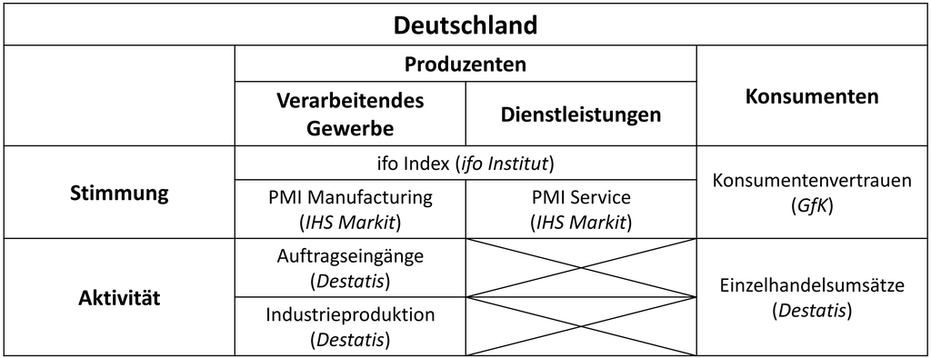

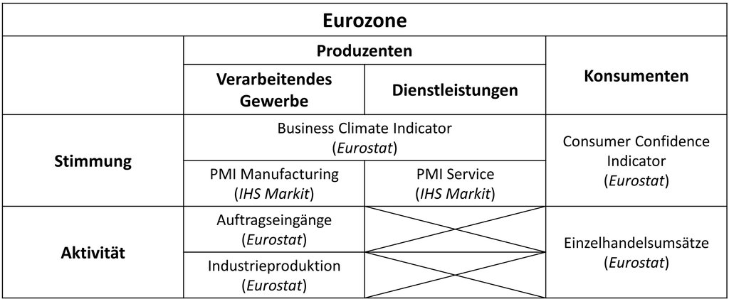

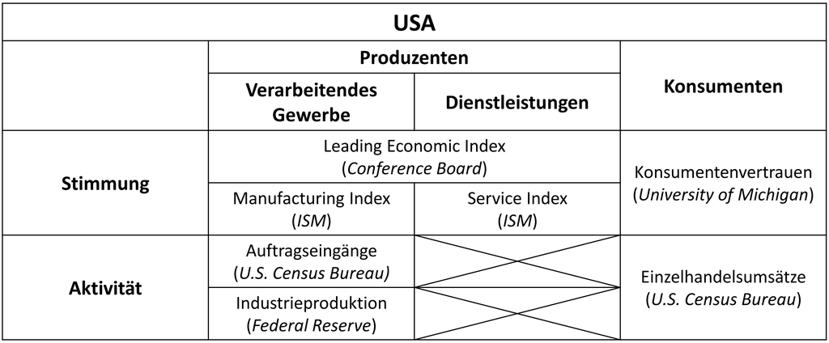

Zurück zur *Startseite*

## Vorbereitung

Die Veröffentlichungen der Umfragen der wichtigsten *Stimmungsindikatoren* werden zum größten Teil aus dem Internet heruntergeladen und eingebunden. ([siehe](https://github.com/mmoessler/macro-dashboard/blob/main/r-scripts/r_web_scraping_functions.R))

Die Werte der wichtigsten *Aktivitätsindikatoren* werden zum größten Teil von öffentlich zugänglichen Datenbanken herunterladen, aufereitet und dargestellt.

Dabei können die Daten entweder auf der entsprechenden Website oder über so genannte Programmierschnittstellen (APIs) heruntergeladen werden.

Für das Herunterladen der Daten über die APIs von [FRED](https://fred.stlouisfed.org/docs/api/fred/) und [eurostat](https://ec.europa.eu/eurostat/de/data/web-services) und die Darstellung der Daten müssen die folgenden Schritte zur Vorbereitung durchgeführt werden.

Schritt 1: Setze dein Arbeitsverzeichniss

```r
setwd("... insert-you-directory-here ...")
```

Schritt 2: Lade Pakete zum Herungeralden der Daten

```r
library(eurostat)
library(fredr)
```

Schritt 3: Registriere dich bei *FRED* und fordere eines API Schlüssels an

1. [FRED Konto](https://fredhelp.stlouisfed.org/fred/account/fred-account-features/register/)
2. [API Schlüssel](https://fred.stlouisfed.org/docs/api/api_key.html)

```r
fredr_set_key("... insert-your-personal-key-here ...")
```

Schritt 4: Lade Pakete zur Verarbeitung der heruntergeladenen Daten

```r
library(dplyr)
library(tidyr)
library(ggplot2)
library(scales)
library(zoo)
library(kableExtra)
```

Schritt 5: Lade Funktion zur Darstellung der Daten

Funktion zur Schattierung der US Rezessionen:

```r
# See: https://rpubs.com/FSl/609471 (and edited by MM)
add_rec_shade <- function(st_date, ed_date, shade_color = "darkgray", zoo.mon = FALSE, zoo.qtr = FALSE) {

  library(fredr)
  library(ecm)
  library(ggplot2)
  library(zoo)

  # fredr_set_key("insert_your_api_key")
  #
  # st_date <- as.Date("2001-06-01")
  # ed_date <- as.Date(Sys.Date())

  recession  <-  fredr(series_id = "USRECD",observation_start = as.Date(st_date),observation_end = as.Date(ed_date))

  recession$diff <- recession$value-lagpad(recession$value, k = 1)
  recession <- recession[!is.na(recession$diff),]
  recession.start <- recession[recession$diff == 1,]$date
  recession.end <- recession[recession$diff == (-1),]$date

  if(length(recession.start) > length(recession.end)) {
    recession.end <- c(recession.end, Sys.Date())
  }
  if(length(recession.end)>length(recession.start)) {
    recession.start <- c(min(recession$date), recession.start)
  }

  recs <- as.data.frame(cbind(recession.start, recession.end))
  recs$recession.start <- as.Date(as.numeric(recs$recession.start), origin = as.Date("1970-01-01"))

  if(zoo.mon == TRUE){
    recs$recession.start <- as.yearmon(recs$recession.start, "%b%y")
  }
  if(zoo.qtr == TRUE){
    recs$recession.start <- as.yearqtr(recs$recession.start, "%y-Q%q")
  }

  recs$recession.end <- as.Date(recs$recession.end, origin = as.Date("1970-01-01"))

  if(zoo.mon == TRUE){
    recs$recession.end <- as.yearmon(recs$recession.end, "%b%y")
  }
  if(zoo.qtr == TRUE){
    recs$recession.end <- as.yearqtr(recs$recession.end, "%y-Q%q")
  }

  if(nrow(recs) > 0) {
    rec_shade <- geom_rect(data = recs, inherit.aes = FALSE,
                           aes(xmin = recession.start, xmax = recession.end, ymin = -Inf, ymax = +Inf),
                           fill = shade_color, alpha = 0.5)

    return(rec_shade)
  }

}
```

Schritt 6: Lade Grafikvorlage zur Darstellung der Daten

```r
mod.theme.01 <- theme_gray() + theme(axis.text.x = element_text(angle = 90, vjust = 0.5, size = 12),
                                     axis.text.y = element_text(size = 12),
                                     plot.title = element_text(size = 16),
                                     plot.subtitle = element_text(size = 12),
                                     plot.caption = element_text(size = 12),
                                     legend.text = element_text(size = 12))

mod.theme.01$legend.position <- c("bottom")
```

Zurück zur *Startseite*

## Simmung

### Produzenten

#### Ifo Geschäftsklima

Ifo Geschäftsklima Index

Überblick

- Einordnung: Produzenten (generell)
- Region: Deutschland
- Herausgeber: Ifo-Institut ([siehe](https://www.ifo.de/umfrage/ifo-geschaeftsklimaindex))

Weitere Informationen

Der *Ifo Geschäftsklima Index* ist eine der wichtigsten Messzahlen für die Stimmung bei den deutschen Produzenten.

Ergebnisse

[figure not shown]

Quelle: Ifo Institut

Zurück zur *Startseite*

#### EU Sentiment

EU Sentiment

Überblick

- Einordnung: Produzenten (generell) und Konsumenten
- Region: EU und Eurozone
- Herausgeber: Europäische Kommission ([siehe](https://ec.europa.eu/info/business-economy-euro/indicators-statistics/economic-databases/business-and-consumer-surveys/download-business-and-consumer-survey-data/press-releases_de))

Weitere Informationen

Die Stimmungsindikatoren von der *Europäischen Kommission* sind eine der wichtigsten Messzahlen für die Stimmung in der Wirtschaft der EU und Eurozone.

Die Stimmung in der gesamten Wirtschaft (Produzenten und Konsumenten) wird durch das “*Wirtschaftsvertrauen*” (“*Economic Sentiment*”) dargestellt.

Ein wichtiger Teil des generellen “*Wirtschaftsvertrauens*” ist das “*Konsumentenvertrauen*” (“*Consumer Confidence*”).

Ein weiterer wichtiger Teil des generellen “*Wirtschaftsvertrauens*” ist das “*Unternehmensvertrauens*” (“*Business Confidence*”).

Ergebnisse

[figure not shown]

Quelle: Europäische Kommission

Zurück zur *Startseite*

#### ISM EMIs (USA)

ISM Einkaufsmanagerindizes (EMI/PMI)

Überblick

- Einordnung: Anbieter, veratbeitendes Gewerbe und Dienstleistungen
- Region: USA
- Herausgeber: Institute for Supply Management (ISM) ([siehe](https://www.ismworld.org/supply-management-news-and-reports/reports/ism-report-on-business/))

Weitere Informationen

Die *Einkaufsmanagerindizes* vom Instiute for Supply Management (ISM) sind eine der wichtigsten Messzahlen für die Stimmung bei den US Produzenten.

Es gibt zwei Umfragen, eine im *verarbeitenden Gewerbe* sowie eine im *Dienstleistungssektor*.

Ergebnisse

[figure not shown]

Quelle: ISM Institut

[figure not shown]

Quelle: ISM Institut

Zurück zur *Startseite*

### Konsumenten

#### GfK Konsumklima

GfK Konsumklima

Überblick

- Einordnung: Konsumenten
- Region: Deutschland
- Herausgeber: GfK ([siehe](https://www.gfk.com/de/home))

Weitere Informationen

Das *GfK Konsumentenvertrauen* ist eine der wichtigsten Messzahlen für die Stimmung bei den deutschen Konsumenten.

Ergebnisse

[figure not shown]

Quelle: GfK

Zurück zur *Startseite*

#### UoM Consumer Confidence

UoM Consumer Confidence

Überblick

- Einordnung: Konsumenten
- Region: USA
- Herausgeber: University of Michigan ([siehe](https://data.sca.isr.umich.edu/))

Weitere Informationen

Das *UoM Konsumentenvertrauen* ist eine der wichtigsten Messzahlen für die Stimmung bei den US Konsumenten.

Ergebnisse

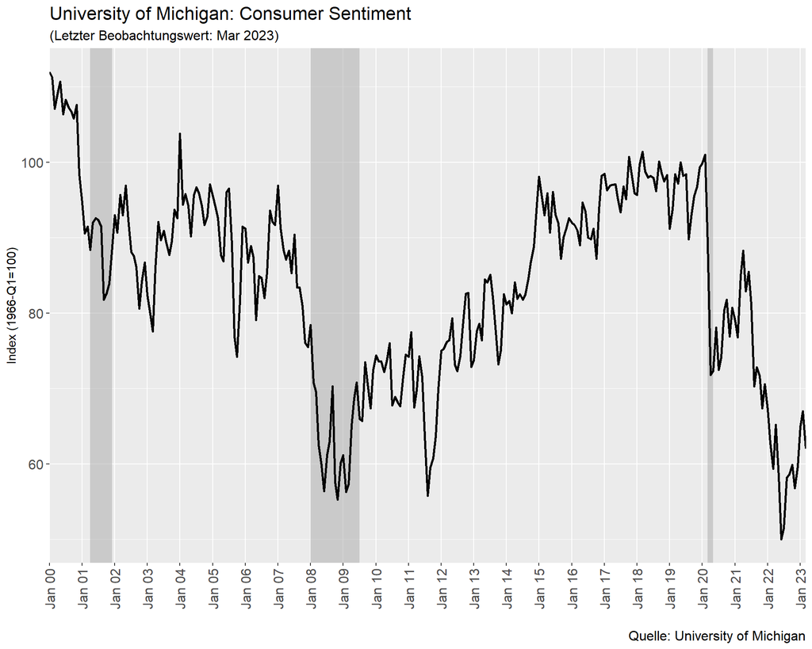

| Datum | Wert |
| --- | --- |
| Oct 2022 | 59,9 |
| Nov 2022 | 56,8 |
| Dec 2022 | 59,7 |
| Jan 2023 | 64,9 |
| Feb 2023 | 67,0 |
| Mar 2023 | 62,0 |

```r
# Meta data
met.dat <- fredr_series_search_text("UMCSENT")

# Data
ser.dat <- fredr_series_observations(series_id = met.dat$id[1],
                                     observation_start = as.Date("2000-01-01"),
                                     units = "lin")
# Transform date to yearmon class
ser.dat$date.zoo <- as.yearmon(ser.dat$date, "%b%y")

# Construct plot
plot <- ggplot(data = ser.dat, mapping = aes(x = date.zoo, y = value,color = series_id)) +
  add_rec_shade(min(ser.dat$date), max(ser.dat$date), zoo.mon = TRUE, zoo.qtr = FALSE) +
  geom_line(color = "black", size = 1) +
  scale_y_continuous(name = "Index (1966-Q1=100)", labels = comma) +
  scale_x_yearmon(breaks=seq(from = min(ser.dat$date.zoo), to = max(ser.dat$date.zoo), by = 1),
                  minor_breaks = seq(from = min(ser.dat$date.zoo), to = max(ser.dat$date.zoo), by = 1),
                  format = "%b %y",
                  expand = c(0, 0)) +
  labs(title = met.dat$title[1],
       subtitle = paste0(c("(Letzter Beobachtungswert: "), as.yearmon(as.Date(met.dat$observation_end)), c(")")),
       caption = "Quelle: University of Michigan",
       x = "", y = "Index (1966-Q1=100)") +
  mod.theme.01


# Return plot
plot
```

Zurück zur *Startseite*

## Aktivität

### Produzenten

#### EU Industrieproduktion

EU Industrieproduktion

Überblick

- Einordnung: Produzenten, verarbeitendes Gewerbe
- Region: EU Mitgliedstaaten
- Herausgeber: Eurostat ([siehe](https://ec.europa.eu/eurostat/de/home))
- Bereinigung: Saison-, kalender- und preisbereinigung

Weitere Informationen

Die Industrieproduktion ist die wichtigste Messzahl um die Aktivität bei den Produzenten darzustellen.

Werte

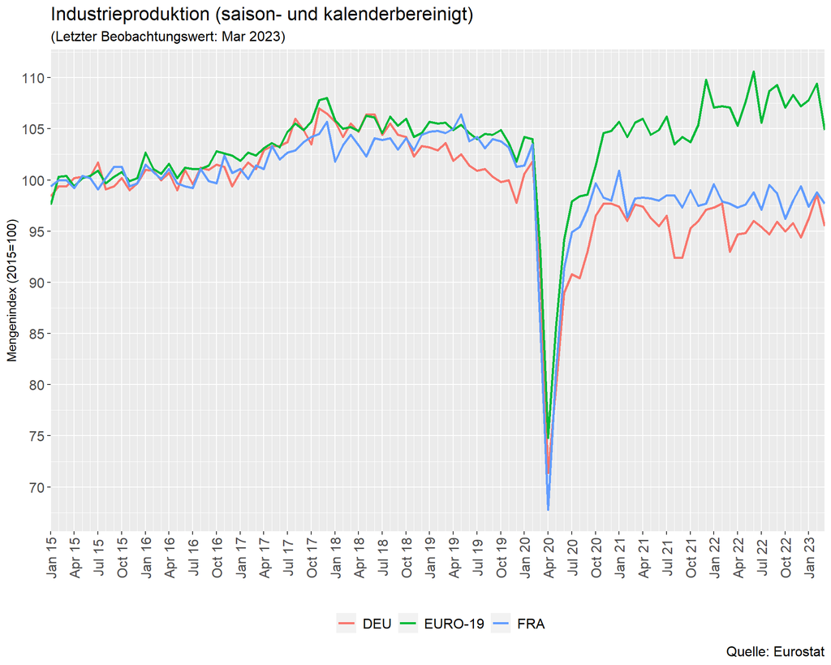

| Zeitraum | DEU | FRA | EURO-19 |
| --- | --- | --- | --- |
| Jun 2022 | 96,0 | 98,8 | 110,6 |
| Jul 2022 | 95,4 | 97,1 | 105,6 |
| Aug 2022 | 94,7 | 99,5 | 108,7 |
| Sep 2022 | 95,9 | 98,7 | 109,3 |
| Oct 2022 | 95,0 | 96,2 | 107,1 |
| Nov 2022 | 95,8 | 98,0 | 108,3 |
| Dec 2022 | 94,4 | 99,4 | 107,2 |
| Jan 2023 | 96,2 | 97,4 | 107,8 |
| Feb 2023 | 98,6 | 98,8 | 109,4 |
| Mar 2023 | 95,5 | 97,7 | 104,9 |

```r
source("./r-scripts/r_eurostat_helper_functions.R")

# Url
url <- "https://ec.europa.eu/eurostat/api/dissemination/statistics/1.0/data/sts_inpr_m?format=JSON&geo=DE&geo=FR&geo=EA19&freq=M&unit=I15&s_adj=SCA&indic_bt=PROD&nace_r2=B-D"

# Data
ser.dat <- get_eurostat_xx(url = url)

# Transform date to date class
ser.dat$date.dat <- as.Date(as.yearmon(ser.dat$time))
# Transform date to yearmon class
ser.dat$date.zoo <- as.yearmon(ser.dat$date.dat, "%b%y")

# Subset data
ser.dat <- subset(ser.dat, date.dat %in% seq(as.Date("2015-01-01"), Sys.Date(), by = "month"))

# Construct plot
plot <- ggplot(data = ser.dat, mapping = aes(x = date.zoo, y = values, color = geo)) +
  geom_line(size = 1) +
  scale_x_yearmon(breaks = seq(from = min(ser.dat$date.zoo), to = max(ser.dat$date.zoo), by = 3/12),
                  minor_breaks = seq(from = min(ser.dat$date.zoo), to = max(ser.dat$date.zoo), by = 1/12),
                  format = "%b %y",
                  expand = c(0, 0)) +
  scale_y_continuous(breaks = seq(0, 200, 5)) +
  scale_color_discrete(name = "", labels = c("DEU","EURO-19","FRA")) +
  labs(title = "Industrieproduktion (saison- und kalenderbereinigt)",
       subtitle = paste0(c("(Letzter Beobachtungswert: "), as.yearmon(as.Date(ser.dat$date.dat[length(ser.dat$time)])), c(")")),
       caption = "Quelle: Eurostat",
       x = "", y = "Mengenindex (2015=100)") +
  mod.theme.01

# Return plot
plot
```

Zurück zur *Startseite*

#### US Industrieproduktion

USA Industrieproduktion

Überblick

- Einordnung: Produzenten
- Region: USA
- Herausgeber: Board of Governors of the Federal Reserve System ([siehe](https://www.federalreserve.gov/releases/g17/current/default.htm))
- Bereinigung: Saison- und preisbereinigung, keine kalenderbereingung

Weitere Informationen

Die Industrieproduktion ist die wichtigste Messzahl um die Aktivität bei den Produzenten darzustellen.

Ergebnisse

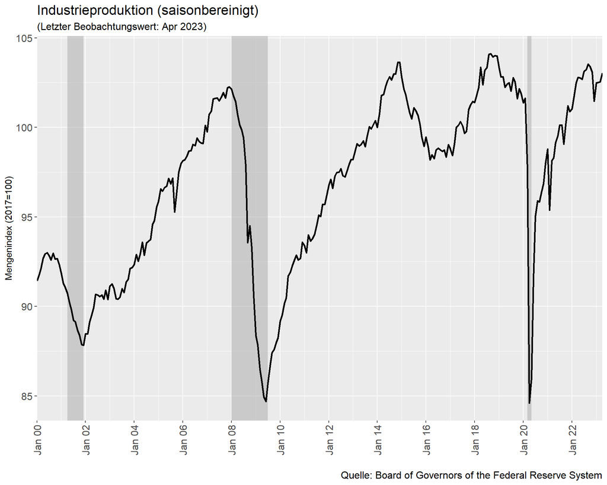

| Zeitraum | Wert |
| --- | --- |
| Jul 2022 | 103,13 |
| Aug 2022 | 103,23 |
| Sep 2022 | 103,53 |
| Oct 2022 | 103,41 |
| Nov 2022 | 103,07 |
| Dec 2022 | 101,47 |
| Jan 2023 | 102,50 |
| Feb 2023 | 102,50 |
| Mar 2023 | 102,55 |
| Apr 2023 | 103,04 |

```r
# Meta data
met.dat <- fredr_series_search_text("INDPRO")

# Data
ser.dat <- fredr_series_observations(series_id = met.dat$id[1],
                                     observation_start = as.Date("2000-01-01"),
                                     units = "lin")

# Transform date to yearmon class
ser.dat$date.zoo <- as.yearmon(ser.dat$date, "%b%y")

# Construct plot
plot <- ggplot(data = ser.dat, mapping = aes(x = date.zoo, y = value, color = series_id)) +
  add_rec_shade(min(ser.dat$date), max(ser.dat$date), zoo.mon = TRUE, zoo.qtr = FALSE) +
  geom_line(color = "black", size = 1) +
  scale_x_yearmon(breaks = seq(from = min(ser.dat$date.zoo), to = max(ser.dat$date.zoo), by = 1),
                  minor_breaks = seq(from = min(ser.dat$date.zoo), to = max(ser.dat$date.zoo), by = 1),
                  format = "%b %y",
                  expand = c(0, 0)) +
  labs(title = "Industrieproduktion (saisonbereinigt)",
       subtitle = paste0(c("(Letzter Beobachtungswert: "), as.yearmon(as.Date(met.dat$observation_end)), c(")")),
       caption = "Quelle: Board of Governors of the Federal Reserve System",
       x = "", y = "Mengenindex (2017=100)") +
  mod.theme.01

# Return plot
plot
```

Zurück zur *Startseite*